# Lesson 12 - Factors and Dates

Stats 20 – Section 1 – Vivian Lew

Due 7/25/2020 by 11:59PM PDT

# 1. Introduction to Lesson 12

## Recall from lecture, a quick summary of factors:

- Factors are variables in R which take on a limited number of different values (levels), typically these variables are called non-numerical or “categorical” variables.
- We use factors in statistical modeling because non-numerical variables (e.g., ancestry and it’s “levels” — African, Asian, European, Other) enter into statistical models differently than numerical variables.
- Designating non-numerical data as factors insures that the modeling functions in R will treat these types of variables correctly.

And why we want to know how to use them:

- Factors allow changes in the order in which the levels are displayed from their default sorted order, characters have more limitations.
- A levels= argument can be given a vector for ALL of the possible values of the variable in the order you desire, even if they are not currently present in the data. This is useful during data collection
- Also, if the ordering of levels is important when performing comparisons (e.g., modeling), use the optional ordered=TRUE argument. In this situation, the factor is known as an ordered factor.

## Dates/Times

- While they have a numeric representation in R (typically, the days or seconds since 1/1/1970), sometimes dates are stored as factors (as opposed to strings) – always check to make sure the function you use converts the factor to character before converting to a datetime (the functions used in this lesson will do that for you).

# 2. The data

The data was collected by the San Francisco Fire Department and a subset – all calls since 1/1/2020 – was extracted BUT to simplify this lesson, only the unit which arrived on the scene first was kept (in reality, multiple units may be sent to an emergency). There are 72856 rows/observations and 32 fields/variables (please verify this for yourself).

## Variables of Interest

Many topics can be examined using the data but from a legal/administrative perspective, the amount of time it takes on average to respond to an emergency may be the most controversial. San Francisco is one of the few cities which makes much of it’s data available publicly. The following may be the most interesting/useful for an analysis:

Received.DtTm - date/time the call was received by 9-1-1 dispatch  
Response.DtTm - date/time when a unit responded to the dispatch operator  
On.Scene.DtTm - date/time when a unit arrived at the callers location  
Hospital.DtTm - if someone needed hospitalization, this is the date/time when a unit arrived at the hospital

## Example reading of the data

In lecture, you were shown how to convert a datetime variable into an R DateTime by using a function called as.POSIXct( ) which will convert the datetime string into something both base R and dplyr can use (so you can choose).

For example, here is how you could convert Received.DtTm and save the converted values as a new column on your existing data frame. I’ll call it “START” as for this lesson, this marks the start time of the request for emergency assistance.

```r
load("Lesson12.RData")
FD12$START <- as.POSIXct(FD12$Received.DtTm,
                           format = "%m/%d/%Y %I:%M:%S %p")
```

We could explore the data and some simple plots might help us visualize the time component and it’s relation to emergency request volume. The package lubridate might be helpful here because we could convert the dates to “day of the year” with the yday function:

```r
library(lubridate)
FD12$daySTART <- yday(FD12$START)
```

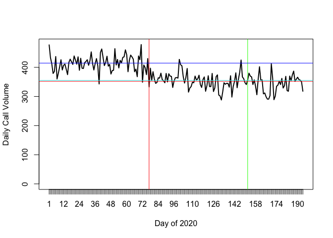

```r
plot(table(FD12$daySTART), type = "l",
     xlab = "Day of 2020", ylab = "Daily Call Volume")
abline(v = 77, col = "red")
abline(v = 152, col = "green")
abline(h = median(table(FD12$daySTART[FD12$daySTART < 77])), col = "blue")
abline(h = median(table(FD12$daySTART[FD12$daySTART >= 77 & FD12$daySTART < 152])), col = "cyan")
abline(h = median(table(FD12$daySTART[FD12$daySTART >= 152])), col = "red")
```

(a thought question, no answers required) What might we say about emergency calls in this historical time period?

A little extra – base R plot has numerous other functions, segments() and text() can be useful here to give the graphic a little more “polish” (it’s not required for your submission). The plot only has the line and all of the annotations have been removed – this will allow us to add them back in under our full control using the axis() and title() functions.

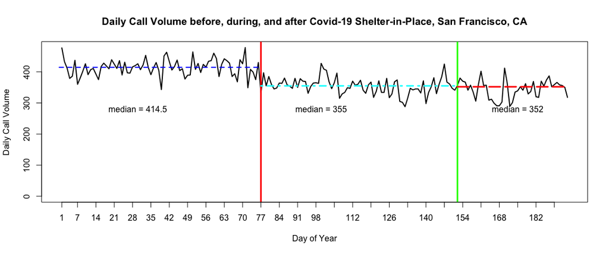

```r
plot(table(FD12$daySTART), type = "l", xaxt = "n", ann = FALSE)
abline(v = 77, col = "red", lwd = 3)
abline(v = 152, col = "green", lwd = 3)
segments(x0= 0, y0= 414.5, x1= 77, y1= 414.5, col= "blue", lwd= 2, lty= 2)
text(30, 280, "median = 414.5")
segments(x0= 77, y0= 355, x1= 152, y1= 355, col= "cyan", lwd= 3, lty= 4)
text(100, 280, "median = 355")
segments(x0= 152, y0= 352, x1= 194, y1= 352, col= "red", lwd= 3, lty= 5)
text(175, 280, "median = 352")
axis(1, at=c(1, seq(from = 7, to = 194, by = 7)),
     labels=c(1, seq(from = 7, to = 194, by = 7)))
title(xlab = "Day of Year", ylab = "Daily Call Volume",
     main = "Daily Call Volume before, during, and after Covid-19 Shelter-in-Place, San Francisco, CA")
```

# 3. Question: Do differences in response times exist and if so, where?

There are several date time variables, but to keep things relatively simple, just focus on these 4 and please convert them to datetime variables (they are currently factors):

Received.DtTm - date/time the call was received by 9-1-1 dispatch  
Response.DtTm - date/time when a unit responded to the dispatch operator  
On.Scene.DtTm - date/time when a unit arrived at the callers location  
Hospital.DtTm - if someone needed hospitalization, this is the date/time when a unit arrived at the hospital

and use them to construct some measures of time. Here is my example (but I won’t show the code). I just want to know the amount of time elapsed between

Received.DtTm and  
Response.DtTm

A simple difference will be sufficient, but both variables should be converted to an R DateTime variable first. I’ll call my time difference SE1. I won’t show you how to do it, but we can check it together:

```r
library(DT)
set.seed(1)
datatable(FD12[sample(nrow(FD12), 10), c("Received.DtTm", "Response.DtTm", "SE1")])
```

|  | Received.DtTm | Response.DtTm | SE1 |
| --- | --- | --- | --- |
| 24388 | 02/28/2020 07:58:25 PM | 02/28/2020 08:01:26 PM | 181 |
| 59521 | 06/03/2020 11:31:06 PM | 06/03/2020 11:34:50 PM | 224 |
| 43307 | 04/18/2020 03:18:00 PM | 04/18/2020 03:20:44 PM | 164 |
| 69586 | 07/03/2020 08:04:40 PM | 07/03/2020 08:05:26 PM | 46 |
| 11571 | 01/29/2020 08:50:48 AM | 01/29/2020 08:53:30 AM | 162 |
| 25173 | 03/01/2020 05:37:05 PM | 03/01/2020 05:39:40 PM | 155 |
| 32618 | 03/20/2020 06:52:02 AM | 03/20/2020 06:58:55 AM | 413 |
| 13903 | 02/03/2020 04:51:44 PM | 02/03/2020 04:58:38 PM | 414 |
| 8229 | 01/21/2020 04:18:26 AM | 01/21/2020 04:21:49 AM | 203 |
| 25305 | 03/02/2020 02:00:24 AM | 03/02/2020 02:04:24 AM | 240 |

SE1 then is the elapsed time in seconds between the received time of the call and the response (acknowledgement) by the Fire Department. I’ll teach you a little about sampling this week, but we took a random sample of size 10 from FD12, set.seed(1) allows us to replicate the sample exactly so that when you run that chunk, you will get the same 10 values.

## Examining the Descriptive Statistics

After I have created SE1, I can examine SE1 differences by a variable such as Supervisor.District (San Francisco is divided into districts for governing, see https://sfgov.org/ccsfgsa/sites/default/files/2000%20Census%3A%20Redistricting%20Task%20Force/ShowImage__67e5.jpg for an idea of what a supervisor district means)

```r
library(dplyr)
FD12 %>%
  select(Supervisor.District, daySTART, SE1) %>%
  group_by(Supervisor.District, daySTART < 77) %>%
  summarise(n = n(),
            median = median(SE1),
            IQR = IQR(SE1)) %>%
  arrange(Supervisor.District)
```

```
## # A tibble: 24 x 5
## # Groups:   Supervisor.District [12]
##    Supervisor.District `daySTART < 77`     n median     IQR
##    <chr>               <lgl>           <int> <drtn>   <dbl>
##  1 1                   FALSE            1758 173 secs  122
##  2 1                   TRUE             1287 177 secs  123
##  3 10                  FALSE            4197 172 secs  139
##  4 10                  TRUE             2779 179 secs  118.
##  5 11                  FALSE            1757 175 secs  136
##  6 11                  TRUE             1325 175 secs  118
##  7 2                   FALSE            2537 179 secs  115
##  8 2                   TRUE             1722 179 secs  112
##  9 3                   FALSE            4127 165 secs  136
## 10 3                   TRUE             3685 171 secs  130
## # … with 14 more rows
```

[output not shown]

## Examining Visualizations

When creating visualizations using time variables, something like this could happen – my boxplots are crushed by the outliers:

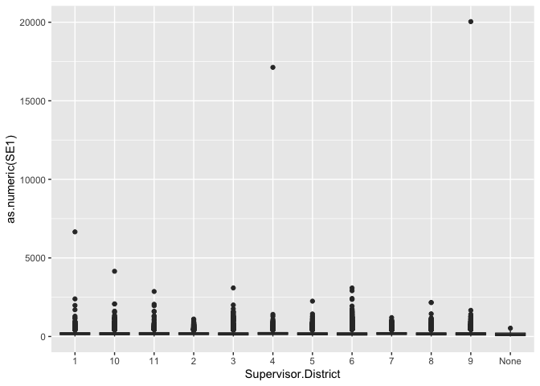

```r
library(ggplot2)
ggplot(data = FD12, aes(x = Supervisor.District, y = as.numeric(SE1))) +
    geom_boxplot()
```

or my densities are too highly skewed because of outliers:

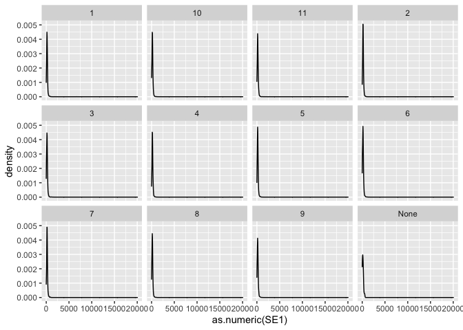

```r
ggplot(data = FD12, aes(x = as.numeric(SE1))) +
    geom_density() +
    facet_wrap(~ Supervisor.District)
```

This “crushing” or “skewness” is too extreme and we lose information. I’ll suggest (a) avoid this information loss if possible and (b) that we might study the common and the extreme separately.

So it turns out that a reponse time difference of more than 600 seconds (about 10 minutes) happens less than 1% of the time, so I’ll exclude those for convenience (this isn’t great data science so if you want to analyze the extremes for this lesson, be my guest). This example shows you how to pass the data directly to ggplot. The period (.) is just a placeholder, it stands for the data which was modified and then passed to ggplot.

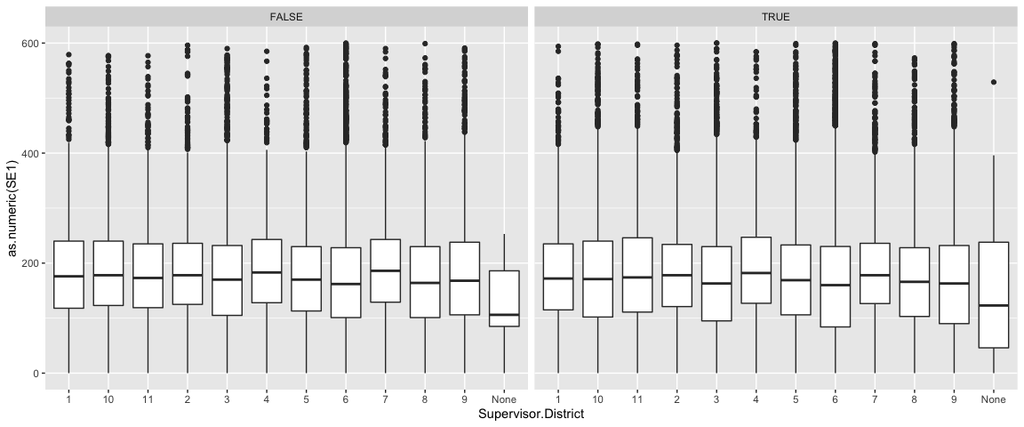

```r
FD12 %>%
select(SE1, Supervisor.District, daySTART)  %>%
filter(SE1 <= 600) %>%
ggplot(data = ., aes(x = Supervisor.District, y = as.numeric(SE1))) +
    geom_boxplot()+
    facet_wrap(~  daySTART >= 77)
```

We could study the extremes of course:

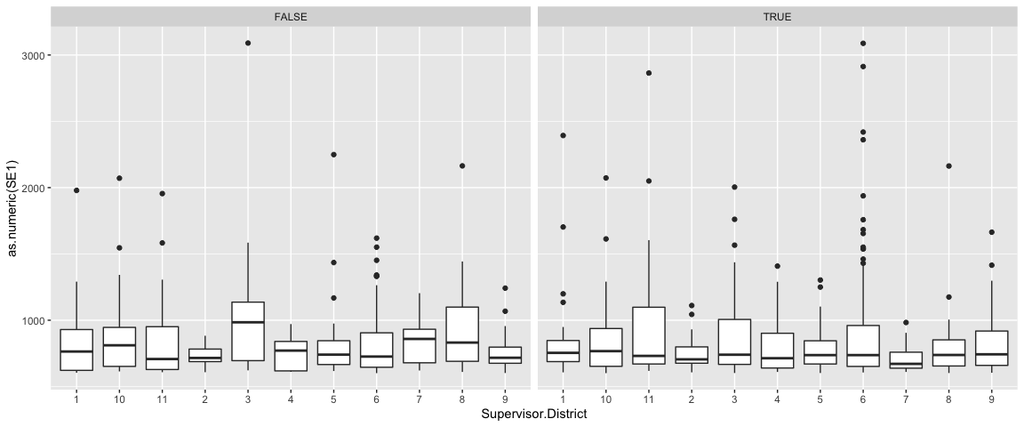

```r
FD12 %>%
select(SE1, Supervisor.District, daySTART)  %>%
filter(SE1 > 600 & SE1 < 3600) %>%
ggplot(data = ., aes(x = Supervisor.District, y = as.numeric(SE1))) +
    geom_boxplot() +
    facet_wrap(~  daySTART >= 77)
```

perhaps the extremes are more interesting…

# 4. Your Turn

Please construct at least one new variable that measures response time. A response time could be something like the amount of time it took for the fire department to arrive at the caller’s location. After you calculate it please demonstrate that you checked it and that it works as you expect it to.

Please examine differences (or no difference) between this time variable and some other characteristic of San Francisco that was captured in this dataset. So for example

Call.Type  
City  
Zipcode.of.Incident  
Battalion  
Original.Priority  
ALS.Unit (whether the unit has life saving equipment)  
and many others in the data

are all variables that **might** be useful in understanding variation in response time.

Your results do not need to be interesting or important, just done (but if you do find something interesting and important, let us know). So to recap, I’ll be looking for:

A. Your ability to work with the DateTime variables  
B. Your ability to deal with factors should you encounter them in your analysis (if you don’t, no problem)  
C. A preliminary analysis (something basic is fine) a visualization is not required, but if you do create one, just keep it simple (ugly is OK)

# 5. What to Turn in For Credit

- A brief analysis of response times (you choose how to measure it and you choose how to explore/examine it, what I am looking for is your ability to work with DateTime variables and factors – the requested conversions were in #3 above). Your analyses should involve a mininum of 3 variables (e.g., my examples used the time the call was received, the time the fire department responded, a computed response time, the supervisor district and whether the emergency occurred before or after the lockdown – so 3 is not too many) and at minimum one table of statistics that allows you to share your findings. If you wish to add a graphic, that would be great but it is not required.
- Name your file Lastname_Firstname_Lesson12.Rmd a model appears in the next link
- Submit your .Rmd file and your .html knitted/rendered result to the appropriate link in Week 4 no later than 7/25/2020 11:59PM PDT. Lessons are not late until they are downloaded for grading, so you can submit after the due date without penalty as I am way behind in grading, however the class ends on 7/31/2020 so that is the absolute last day for credit.